# IODS course project

Ghaida

# Introduction to Open Data Science - Course Project

#**Hello**

- I am a <sup>prospective</sup> student of UH’s *COS: Social Data Science*
- I am very new in this subject and I hope to learn many things that would help me in my future study

[Here](https://github.com/gnazzahra/IODS-project)’s my Github repository: https://github.com/gnazzahra/IODS-project

# 2: Regression and Model Validation

```r
date()
```

```
## [1] "Sun Jun 12 03:27:20 2022"
```

*This week I am learning about data wrangling and linear regression. For the exercise, I have created the learning2014.txt file by doing data wrangling to the full learning2014 data. As the continuation of that exercise, now I will perform regression analysis to the wrangled data and interpret it.*

```r
#reading the data
learning2014 <- read.table("http://s3.amazonaws.com/assets.datacamp.com/production/course_2218/datasets/learning2014.txt", sep=",", header=TRUE)
dim(learning2014)
```

```
## [1] 166   7
```

```r
str(learning2014)
```

```
## 'data.frame':    166 obs. of  7 variables:
##  $ gender  : chr  "F" "M" "F" "M" ...
##  $ age     : int  53 55 49 53 49 38 50 37 37 42 ...
##  $ attitude: num  3.7 3.1 2.5 3.5 3.7 3.8 3.5 2.9 3.8 2.1 ...
##  $ deep    : num  3.58 2.92 3.5 3.5 3.67 ...
##  $ stra    : num  3.38 2.75 3.62 3.12 3.62 ...
##  $ surf    : num  2.58 3.17 2.25 2.25 2.83 ...
##  $ points  : int  25 12 24 10 22 21 21 31 24 26 ...
```

- Here, we can see that our data was collected from 166 students with 7 variables, which are gender, age, attitude, deep, stra, surf, and points.
- The variable “gender” is a character data with two values which describes the student’s gender, “F” for females and “M” for males.
- The variable “age” is an integer data describing the student’s age.
- The variable “attitude” is a numerical data describing the student’s attitude towards statistics.
- Variables “deep”, “stra”, and “surf” each measures the student’s deep, strategic, and surface approach to learning.
- Variable “points” shows us the student’s exam score

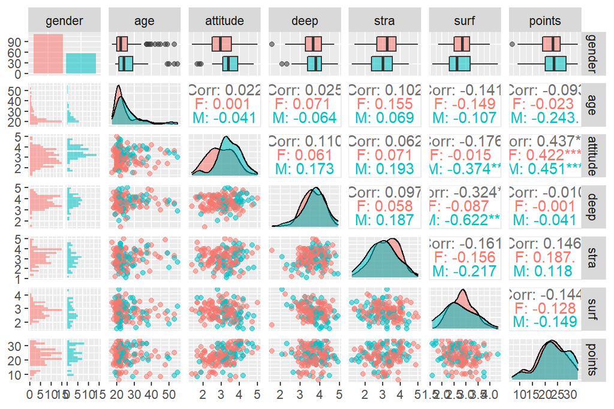

```r
#accessing the libraries
library(ggplot2)
library(GGally)
#drawing scatter plot matrix
p <- ggpairs(learning2014, mapping = aes(col=gender, alpha=0.3), lower = list(combo = wrap("facethist", bins = 20)))
p
```

- The data from female students are represented in pink while the data from male students are represented in green.
- The frequency data shows us that we have more data from female students.
- The highly skewed “age” graph shows us that most of our respondents are very young although we have a few older respondents.
- From the correlation score, we can see that the student’s exam score has the highest correlation to the attitude score. The correlation is positive, which means that students with higher attitude score tends to have higher exam score.
- The second highest correlation is between the student’s exam score and the strategic learning measurement. This correlation is also positive, which means that students who measures higher on strategic learning tends to have higher exam score.
- The third highest correlation is between the student’s exam score and the surface learning measurement. This time, the correlation is negative, which means that students who measures higher on surface learning tends to have lower exam score.

```r
#linear model with three variables as explanatory variables
my_model <- lm(points ~ attitude + stra +surf, data = learning2014)
summary(my_model)
```

```
##
## Call:
## lm(formula = points ~ attitude + stra + surf, data = learning2014)
##
## Residuals:
##      Min       1Q   Median       3Q      Max
## -17.1550  -3.4346   0.5156   3.6401  10.8952
##
## Coefficients:
##             Estimate Std. Error t value Pr(>|t|)
## (Intercept)  11.0171     3.6837   2.991  0.00322 **
## attitude      3.3952     0.5741   5.913 1.93e-08 ***
## stra          0.8531     0.5416   1.575  0.11716
## surf         -0.5861     0.8014  -0.731  0.46563
## ---
## Signif. codes:  0 '***' 0.001 '**' 0.01 '*' 0.05 '.' 0.1 ' ' 1
##
## Residual standard error: 5.296 on 162 degrees of freedom
## Multiple R-squared:  0.2074, Adjusted R-squared:  0.1927
## F-statistic: 14.13 on 3 and 162 DF,  p-value: 3.156e-08
```

- The Rsquared value is 0.2074; the three explanatory variables together accounts for 20.74% of the variation in the student’s exam score.
- The omnibus F statistic has a very low associated p-value, which means that there is a strong evidence that not all three coefficients are zero.
- The p-values of the explanatory variables imply that attitude is strongly associated with the student’s exam scores, while strategic and surface learning measurements seem to not associated with the student’s exam score. Now, we will fit the model with only the significant explanatory variable.

```r
#removing variables that are not statistically significant
my_model <- lm(points ~ attitude, data = learning2014)
summary(my_model)
```

```
##
## Call:
## lm(formula = points ~ attitude, data = learning2014)
##
## Residuals:
##      Min       1Q   Median       3Q      Max
## -16.9763  -3.2119   0.4339   4.1534  10.6645
##
## Coefficients:
##             Estimate Std. Error t value Pr(>|t|)
## (Intercept)  11.6372     1.8303   6.358 1.95e-09 ***
## attitude      3.5255     0.5674   6.214 4.12e-09 ***
## ---
## Signif. codes:  0 '***' 0.001 '**' 0.01 '*' 0.05 '.' 0.1 ' ' 1
##
## Residual standard error: 5.32 on 164 degrees of freedom
## Multiple R-squared:  0.1906, Adjusted R-squared:  0.1856
## F-statistic: 38.61 on 1 and 164 DF,  p-value: 4.119e-09
```

- The Rsquared value is 0.1906, only a little lower than the first model. Attitude alone accounts for 19.06% of the variation in the student’s exam score.
- The regression coefficient of the variable “attitude” changed a little compared to the previous model, but remain highly significant.
- The regression coefficient of the variable “attitude” is 3.5255, which means that for every 1 point increase of the variable “attitude”, there is 3.5255 increase of the variable “points”.
- The fitted model becomes: points = 11.6372 + 3.5255 * attitude

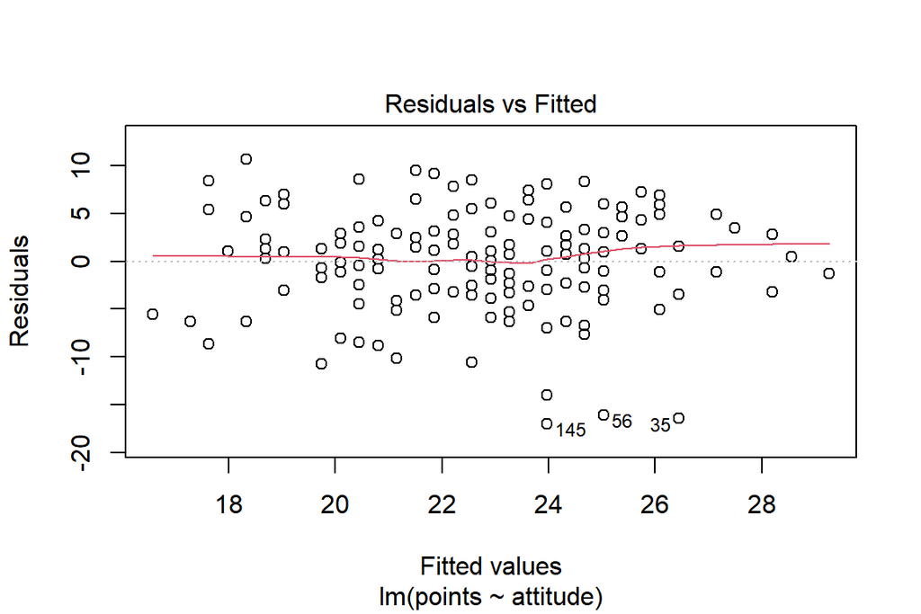

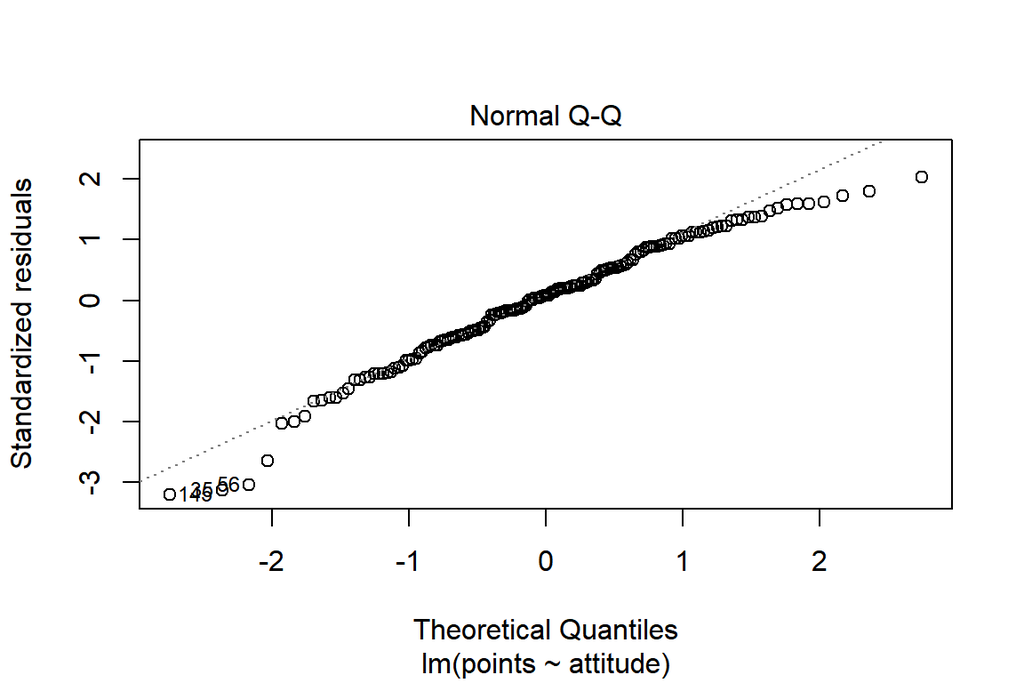

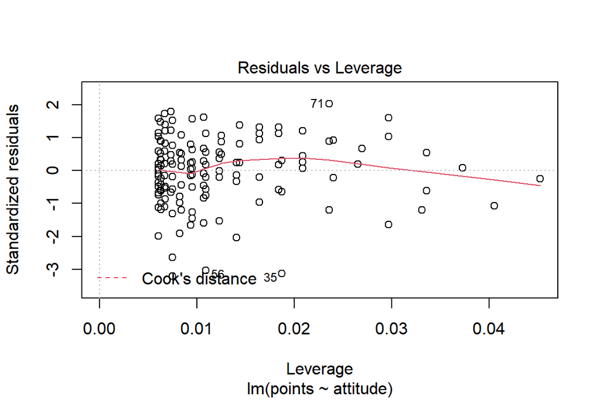

```r
#drawing diagnostic plot
plot(my_model, which=c(1,2,5))
```

- The residual vs fitted plot seems to confirm that the fitted model is appropriate. The variability of the residuals does not seem to significantly increase nor decrease with the size of the fitted values.
- The normal Q-Q plot shows little evidence of departure from linearity, so there is not enough evidence of a departure from normality
- The residual vs leverage plot shows that there are no influential points in the data, as no observation lies outside of the Cook’s distance. This implies that the data does not have any outliers that would impact the model’s coefficients greatly.

# 3: Logistic Regression

```r
date()
```

```
## [1] "Sun Jun 12 03:27:33 2022"
```

*This week I am learning about logistic regression. For the exercise, I have created the alc.csv file by combining and mutating the original UCI Student Performance Data. Now I will do an analysis to the modified data.*

```r
#reading the data
alc <- read.table("https://github.com/rsund/IODS-project/raw/master/data/alc.csv", sep=",", header=TRUE)
dim(alc)
```

```
## [1] 370  51
```

```r
#printing out the names of the variables
str(alc)
```

```
## 'data.frame':    370 obs. of  51 variables:
##  $ school    : chr  "GP" "GP" "GP" "GP" ...
##  $ sex       : chr  "F" "F" "F" "F" ...
##  $ age       : int  15 15 15 15 15 15 15 15 15 15 ...
##  $ address   : chr  "R" "R" "R" "R" ...
##  $ famsize   : chr  "GT3" "GT3" "GT3" "GT3" ...
##  $ Pstatus   : chr  "T" "T" "T" "T" ...
##  $ Medu      : int  1 1 2 2 3 3 3 2 3 3 ...
##  $ Fedu      : int  1 1 2 4 3 4 4 2 1 3 ...
##  $ Mjob      : chr  "at_home" "other" "at_home" "services" ...
##  $ Fjob      : chr  "other" "other" "other" "health" ...
##  $ reason    : chr  "home" "reputation" "reputation" "course" ...
##  $ guardian  : chr  "mother" "mother" "mother" "mother" ...
##  $ traveltime: int  2 1 1 1 2 1 2 2 2 1 ...
##  $ studytime : int  4 2 1 3 3 3 3 2 4 4 ...
```

[output cut: 37 more lines]

- Here, we have a data collected from 370 students with 51 variables.
- This data describes student achievement in secondary education and includes the student’s grades, demographic, social, and school related information.
- G3 is the final year grade of the student, while G2 and G1 are respectively the 1st and 2nd period grades.
- We also have alc_use numeric variable, that shows the average alcohol consumption of the student.
- The variable high_use is a logical variable that shows if the student’s alcohol consumption is high.

*Choose 4 variables and create personal hypothesis:* - goout: students who go out more often would have higher alcohol consumption - sex: males tend to have higher alcohol consumption - absences: students with higher absences would have higher alcohol consumption - studytime: students who spends more time studying would have lower alcohol consumption

```r
#exploring the distribution of the chosen variables
library(tidyr)
library(dplyr)
```

```r
library(ggplot2)

#*alcohol use and go out variable*
#cross-tabulation
alc %>% group_by(goout) %>% summarise(count = n(), mean_alc = mean(alc_use))
```

```
## # A tibble: 5 x 3
##   goout count mean_alc
##   <int> <int>    <dbl>
## 1     1    22     1.41
## 2     2    97     1.56
## 3     3   120     1.71
## 4     4    78     2.14
## 5     5    53     2.73
```

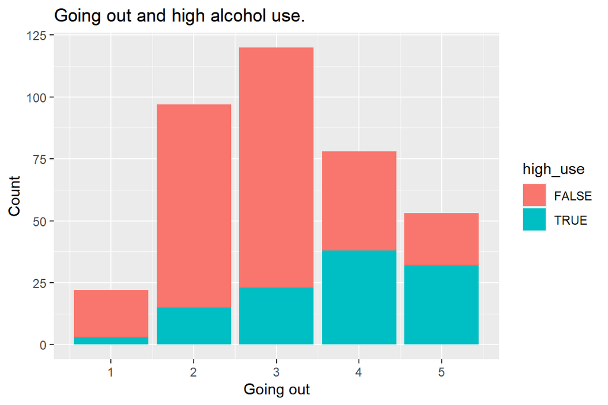

```r
#bar plot
b1 <- ggplot(alc, aes(x = goout, fill=high_use)) + ggtitle("Going out and high alcohol use.")
b1 <- b1 + geom_bar() + labs(x = "Going out", y = "Count")
b1
```

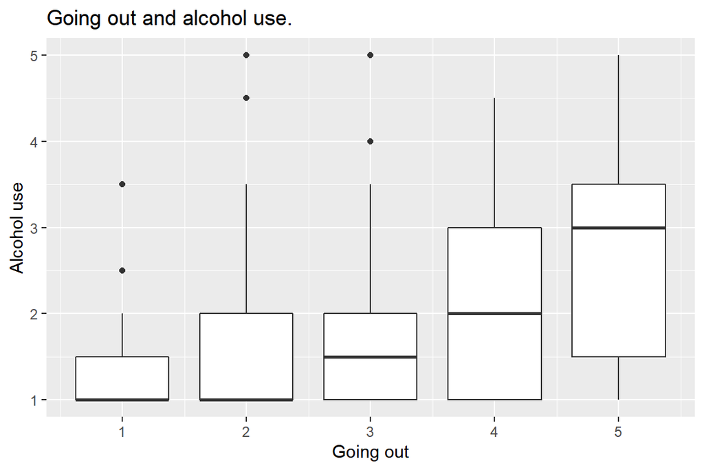

```r
#box plot
g1 <- ggplot(alc, aes(x=goout, y = alc_use, group=goout)) + ggtitle("Going out and alcohol use.")
g1 <- g1 + geom_boxplot() + labs(x = "Going out", y ="Alcohol use")
g1
```

- The cross tabulation, bar plot, and box plot all seems to indicate that students who go out more tend to have higher alcohol consumption
- In the cross tabulation, we can see that the mean of the student’s alcohol consumption is getting higher as the students go out more often.
- The bar plot shows that the proportion of students with high alcohol use generally tends to get higher as the student goes out more often.
- The box plot shows that the median of the student’s alcohol consumption is getting higher as the students go out more often. The range of alcohol use also gets higher.

```r
#*alcohol use and sex variable*
#cross-tabulation
alc %>% group_by(sex) %>% summarise(count = n(), mean_alc = mean(alc_use))
```

```
## # A tibble: 2 x 3
##   sex   count mean_alc
##   <chr> <int>    <dbl>
## 1 F       195     1.62
## 2 M       175     2.19
```

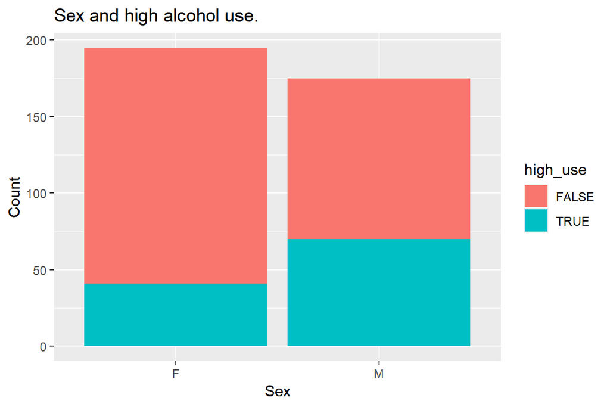

```r
#bar plot
b1 <- ggplot(alc, aes(x = sex, fill=high_use)) + ggtitle("Sex and high alcohol use.")
b1 <- b1 + geom_bar() + labs(x = "Sex", y = "Count")
b1
```

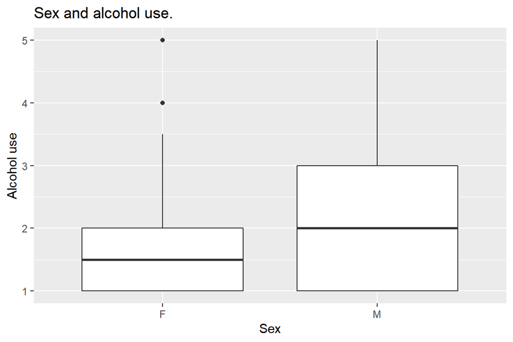

```r
#box plot
g1 <- ggplot(alc, aes(x=sex, y = alc_use, group=sex)) + ggtitle("Sex and alcohol use.")
g1 <- g1 + geom_boxplot() + labs(x = "Sex", y ="Alcohol use")
g1
```

- The cross tabulation, bar plot, and box plot all seem to indicate that male students have higher alcohol consumption.
- In the cross tabulation we see that the average score of male student’s alcohol consumption is 2.19, higher than female student’s alcohol consumption score which is 1.62
- The bar plot shows that male students has more students with high use of alcohol, while female students have more students with low use of alcohol.
- The box plot shows that male student’s median alcohol consumption is higher than female student’s. The range of alcohol consumption is also wider in male students, which means that the data of males students is more diverse.

```r
#*alcohol use and absences variable*
#cross-tabulation
alc %>% group_by(high_use) %>% summarise(count = n(), mean_absences = mean(absences))
```

```
## # A tibble: 2 x 3
##   high_use count mean_absences
##   <lgl>    <int>         <dbl>
## 1 FALSE      259          3.71
## 2 TRUE       111          6.38
```

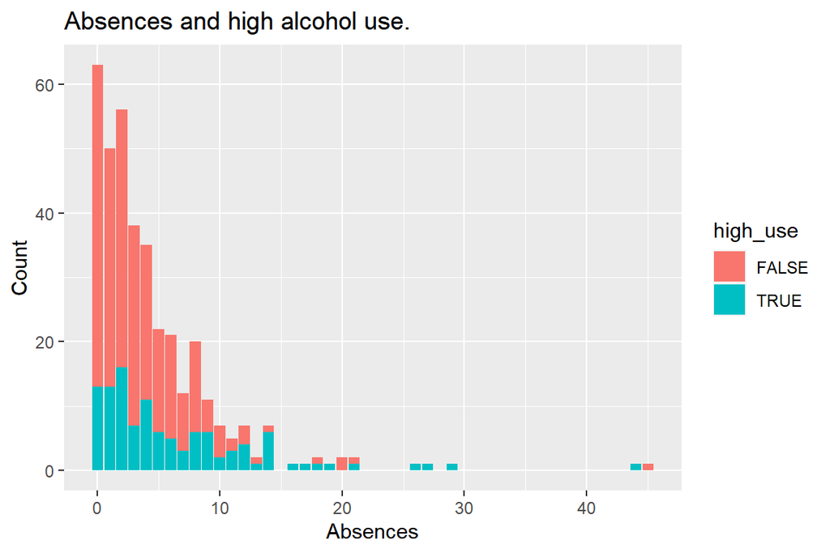

```r
#bar plot
b1 <- ggplot(alc, aes(x = absences, fill=high_use)) + ggtitle("Absences and high alcohol use.")
b1 <- b1 + geom_bar() + labs(x = "Absences", y = "Count")
b1
```

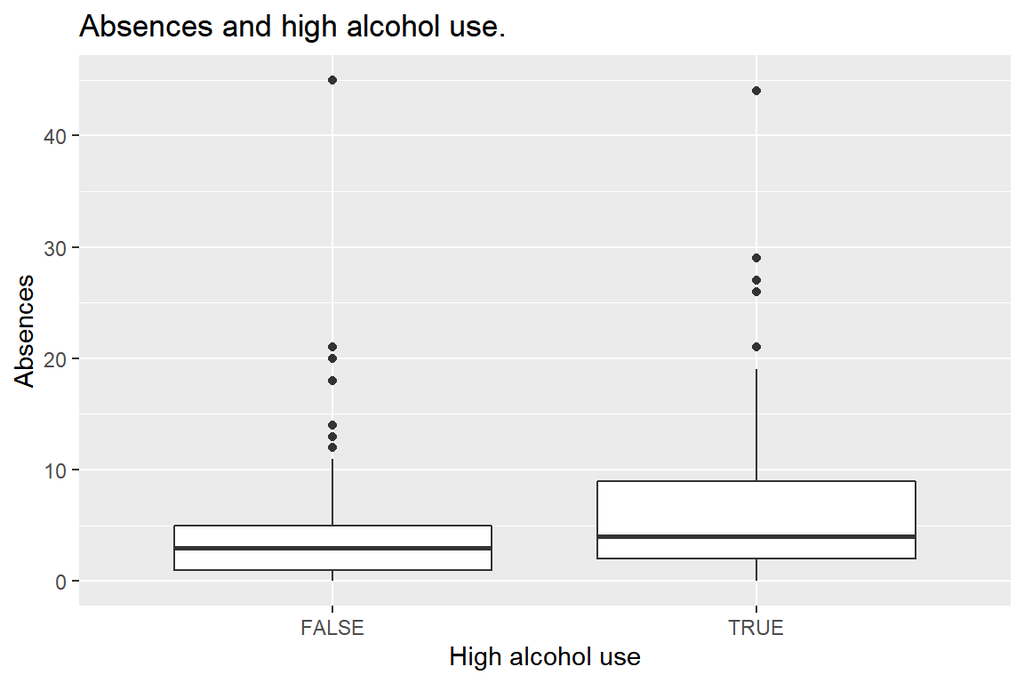

```r
#box plot
g1 <- ggplot(alc, aes(x=high_use, y = absences, group=high_use)) + ggtitle("Absences and high alcohol use.")
g1 <- g1 + geom_boxplot() + labs(x = "High alcohol use", y ="Absences")
g1
```

- Cross tabulation, bar plot, and box plot all seem to indicate that student with high alcohol consumption tend to have higher absences. - In the cross tabulation, we can see that students with high alcohol consumption on average has 6-7 absences, while students with low alcohol consuption has 3-4 absences on average. - Bar plot also shows similar conlusion, where the proportion of students with high alcohol consumption gets higher in groups of students with higher absences. - The box plot shows that the median of absences are higher in students with high alcohol consumption. The data is also more diverse in the high alcohol consumption group.

```r
#*alcohol use and studytime variable*
#cross-tabulation
alc %>% group_by(studytime) %>% summarise(count = n(), mean_alc = mean(alc_use))
```

```
## # A tibble: 4 x 3
##   studytime count mean_alc
##       <int> <int>    <dbl>
## 1         1    98     2.27
## 2         2   185     1.86
## 3         3    60     1.52
## 4         4    27     1.54
```

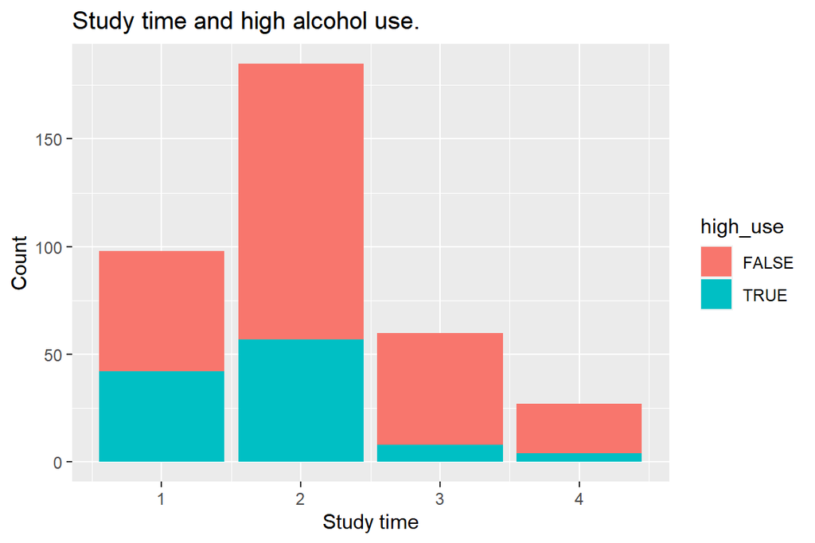

```r
#bar plot
b1 <- ggplot(alc, aes(x = studytime, fill=high_use)) + ggtitle("Study time and high alcohol use.")
b1 <- b1 + geom_bar() + labs(x = "Study time", y = "Count")
b1
```

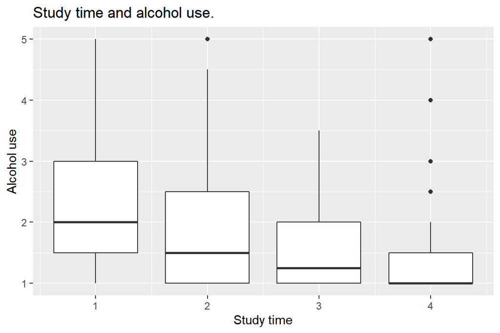

```r
#box plot
g1 <- ggplot(alc, aes(x=studytime, y = alc_use, group=studytime)) + ggtitle("Study time and alcohol use.")
g1 <- g1 + geom_boxplot() + labs(x = "Study time", y ="Alcohol use")
g1
```

- The cross tabulation, bar plot, and box plot all seem to indicate that students who spend more time studying tend to have less alcohol consumption
- In the cross tabulation, we can see that in general the mean alcohol consumption gets is in groups with higher study time. However, although students who spends more than 10 hours/week of studying has on average has a little higher alcohol consumption compared to students who spends 5-10 hours studying each week.
- The bar plot shows that the proportion of students with high alcohol consumption is generally lower in groups of students with higher study time
- The box plot shows that the median of alcohol consumption gets lower as students spend more time studying.

```r
#running logistic regression with the chosen variables
m <- glm(high_use ~ goout + sex + absences + studytime, data=alc, family="binomial")
summary(m)
```

```
##
## Call:
## glm(formula = high_use ~ goout + sex + absences + studytime,
##     family = "binomial", data = alc)
##
## Deviance Residuals:
##     Min       1Q   Median       3Q      Max
## -1.9330  -0.7896  -0.4956   0.7414   2.6125
##
## Coefficients:
##             Estimate Std. Error z value Pr(>|z|)
## (Intercept) -3.19268    0.59956  -5.325 1.01e-07 ***
## goout        0.72483    0.12086   5.997 2.01e-09 ***
## sexM         0.83999    0.27053   3.105 0.001903 **
## absences     0.07853    0.02274   3.454 0.000553 ***
## studytime   -0.43466    0.17177  -2.530 0.011393 *
## ---
## Signif. codes:  0 '***' 0.001 '**' 0.01 '*' 0.05 '.' 0.1 ' ' 1
##
## (Dispersion parameter for binomial family taken to be 1)
##
##     Null deviance: 452.04  on 369  degrees of freedom
## Residual deviance: 367.31  on 365  degrees of freedom
## AIC: 377.31
##
## Number of Fisher Scoring iterations: 4
```

```r
# compute odds ratios (OR)
OR <- coef(m) %>% exp

# compute confidence intervals (CI)
CI <- exp(confint(m))
# print out the odds ratios with their confidence intervals
cbind(OR, CI)
```

```
##                     OR      2.5 %    97.5 %
## (Intercept) 0.04106168 0.01223447 0.1291474
## goout       2.06437847 1.63882768 2.6351100
## sexM        2.31633977 1.36894449 3.9634620
## absences    1.08169564 1.03565150 1.1336977
## studytime   0.64748646 0.45763756 0.8996268
```

- The result shows that going out frequency, sex, number of absences, and time spent studying are all significant predictors of student’s alcohol use.
- Students with higher score of going out are 2.06 times more likely to have high alcohol consumption, with the 95% confidence interval between 1.64-2.63 times more likely. This is in line with the original hypothesis.
- Male students are 2.3 times more likely to have higher alcohol consumption than female students, with the 95% confidence interval between 1.37-3.96 times more likely. This is in line with the original hypothesis.
- Students with higher absences are 1.08 times more likely to have higher alcohol consumption, with the 95% confidence interval between 1.03-1.13 times more likely. Although this variable is highly significant, its odds ratio is not as extreme as it is a numeric variable with a high range of values, and the odds ratio is comparing the n vs n-1 value of the variable, which is only slightly different. In another word, students with n number of absences are 1.08 times more likely to have high alcohol consumption compared to students with n-1 number of absences. This is in line with the original hypothesis.
- Students who spend more time studying are 0.65 times more likely to have high alcohol consumption, with the 95% confidence interval between 0.46-0.90. As the odds ratio is less than 1, it can also be interpreted as: students who spends more time studying are 1.54 (1/0.65) times less likely to have high alcohol consumption. This is inline with the original hypothesis.

```r
# predict() the probability of high_use
probabilities <- predict(m, type = "response")

# add the predicted probabilities to 'alc'
alc <- mutate(alc, probability = probabilities)

# use the probabilities to make a prediction of high_use
alc <- mutate(alc, prediction = probability > 0.5)

# tabulate the target variable versus the predictions
table(high_use = alc$high_use, prediction = alc$prediction)
```

```
##         prediction
## high_use FALSE TRUE
##    FALSE   244   15
##    TRUE     62   49
```

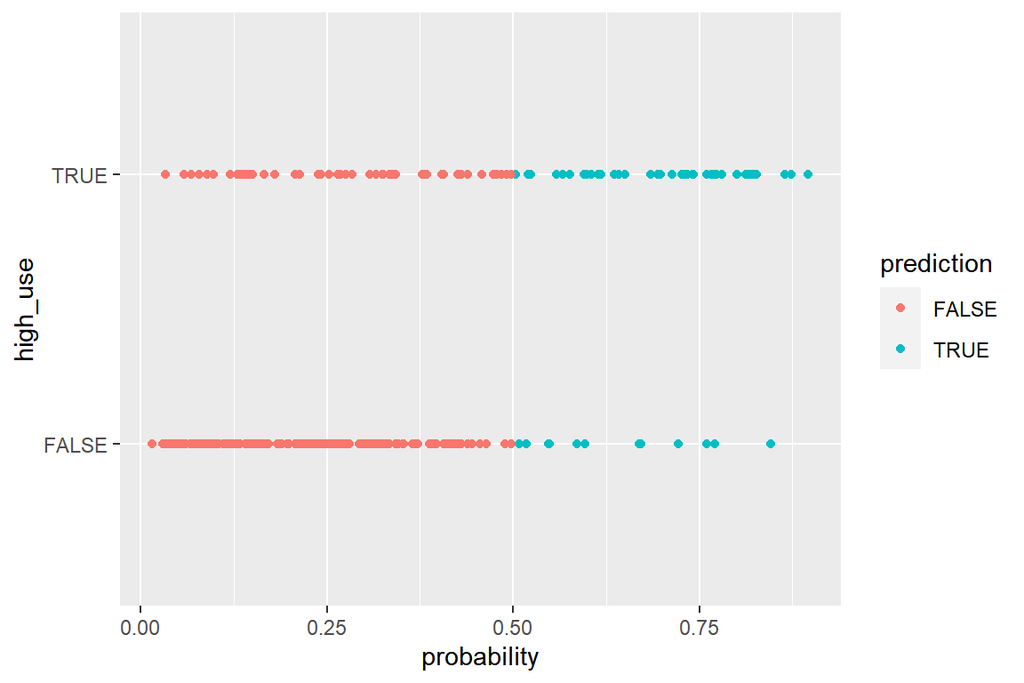

```r
# initialize a plot of 'high_use' versus 'probability' in 'alc'
g <- ggplot(alc, aes(x = probability, y = high_use, col = prediction))

# define the geom as points and draw the plot
g + geom_point()
```

```r
# tabulate the target variable versus the predictions
table(high_use = alc$high_use, prediction = alc$prediction) %>% prop.table %>% addmargins
```

```
##         prediction
## high_use      FALSE       TRUE        Sum
##    FALSE 0.65945946 0.04054054 0.70000000
##    TRUE  0.16756757 0.13243243 0.30000000
##    Sum   0.82702703 0.17297297 1.00000000
```

```r
# define a loss function (mean prediction error)
loss_func <- function(class, prob) {
  n_wrong <- abs(class - prob) > 0.5
  mean(n_wrong)
}

# call loss_func to compute the average number of wrong predictions in the (training) data
loss_func(class = alc$high_use, prob = alc$probability)
```

```
## [1] 0.2081081
```

- Only around 20.8% individuals are classified inaccurately, which means that the prediction of this model is a lot better than simple guessing strategy.
- The proportion of incorrect prediction seems to be higher in high alcohol use group, which may be because the characteristics of individuals with high alcohol use is more diverse.

```r
# compute the average number of wrong predictions in the (training) data
loss_func(class= alc$high_use, prob= alc$probability)
```

```
## [1] 0.2081081
```

```r
# K-fold cross-validation
library(boot)
cv <- cv.glm(data = alc, cost = loss_func, glmfit = m, K = 10)

# average number of wrong predictions in the cross validation
cv$delta[1]
```

```
## [1] 0.2108108
```

```r
#*running logistic regression with the all possible variables*
m1 <- glm(high_use ~ school + sex + age + address + famsize + Pstatus + Medu + Fedu + Mjob + reason + guardian + traveltime + studytime + failures + schoolsup + famsup + paid + activities + nursery + higher + internet + romantic + famrel + freetime + goout + health + absences, data=alc, family="binomial")
summary(m1)
```

```
##
## Call:
## glm(formula = high_use ~ school + sex + age + address + famsize +
##     Pstatus + Medu + Fedu + Mjob + reason + guardian + traveltime +
##     studytime + failures + schoolsup + famsup + paid + activities +
##     nursery + higher + internet + romantic + famrel + freetime +
##     goout + health + absences, family = "binomial", data = alc)
##
## Deviance Residuals:
##     Min       1Q   Median       3Q      Max
## -1.9094  -0.7035  -0.3848   0.5737   2.8620
##
## Coefficients:
##                  Estimate Std. Error z value Pr(>|z|)
## (Intercept)      -3.20651    2.88500  -1.111 0.266377
## schoolMS         -0.44064    0.54874  -0.803 0.421972
## sexM              0.77830    0.32827   2.371 0.017743 *
## age               0.06991    0.14615   0.478 0.632406
## addressU         -0.75282    0.40930  -1.839 0.065873 .
## famsizeLE3        0.50663    0.31843   1.591 0.111607
## PstatusT         -0.13897    0.50413  -0.276 0.782801
## Medu              0.01555    0.21479   0.072 0.942272
## Fedu              0.02343    0.18394   0.127 0.898654
## Mjobhealth       -0.81556    0.72196  -1.130 0.258623
## Mjobother        -0.76489    0.47692  -1.604 0.108759
## Mjobservices     -0.58919    0.54241  -1.086 0.277368
## Mjobteacher      -0.23643    0.66904  -0.353 0.723795
## reasonhome        0.53662    0.38136   1.407 0.159384
## reasonother       1.50578    0.51546   2.921 0.003487 **
## reasonreputation  0.05841    0.40051   0.146 0.884046
## guardianmother   -0.77038    0.35536  -2.168 0.030164 *
## guardianother    -0.04862    0.77000  -0.063 0.949653
## traveltime        0.26812    0.22696   1.181 0.237475
## studytime        -0.25094    0.19731  -1.272 0.203455
## failures          0.20762    0.27250   0.762 0.446115
## schoolsupyes     -0.03841    0.44784  -0.086 0.931644
## famsupyes        -0.06110    0.31461  -0.194 0.846023
## paidyes           0.35414    0.55678   0.636 0.524749
## activitiesyes    -0.58320    0.30566  -1.908 0.056393 .
## nurseryyes       -0.43506    0.36266  -1.200 0.230288
## higheryes         0.07726    0.68562   0.113 0.910276
## internetyes       0.29139    0.43872   0.664 0.506575
## romanticyes      -0.55822    0.32546  -1.715 0.086313 .
## famrel           -0.51794    0.16331  -3.171 0.001517 **
## freetime          0.21469    0.16342   1.314 0.188929
## goout             0.86445    0.14933   5.789 7.08e-09 ***
## health            0.17731    0.11174   1.587 0.112563
## absences          0.08541    0.02553   3.345 0.000823 ***
## ---
## Signif. codes:  0 '***' 0.001 '**' 0.01 '*' 0.05 '.' 0.1 ' ' 1
##
## (Dispersion parameter for binomial family taken to be 1)
##
##     Null deviance: 452.04  on 369  degrees of freedom
## Residual deviance: 322.98  on 336  degrees of freedom
## AIC: 390.98
##
## Number of Fisher Scoring iterations: 5
```